# WeRateDogs

WeRateDogs is a popular Twitter account known for rating and reviewing pictures of dogs submitted by users. The account rates each dog on a scale from 1 to 10 and often includes humorous commentary about the dog in the tweet. The account gained popularity for its quirky and lighthearted approach to dog ratings and has since grown into a well-known social media presence with over 9 million followers.

I analyzed the account and uncovered four insights

## 1.Correlation

The first insight demonstrates the correlation between the 'favorite_count', 'rating_numerator', and 'retweet_count' columns.

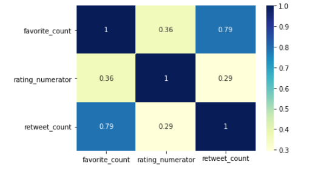

'

the image shows a high correlation between retweet_count and favorite_count

### The most puplouar dog stages

The four main dog stages of the WeRateDogs Twitter account are doggo, floofer, pupper, and puppo.

- Doggo: This term is used to describe a big
- Floofer: This term is used to describe a fluffy and puffy dog,
- Pupper: This term is used to describe a young or small dog
- Puppo: This term is used to describe a dog that is in between the puppy and big stage

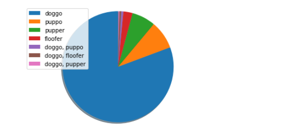

it's clear that doggo is the most puplpuar dog stage on the account

## Source

There are three sources that the people on the WeRateDogs account used to rate the dogs.

- 'Twitter for IPhone'
- 'Twitter for Web'
- 'TweetDeck'

The most used source is ' Twitter for iPhone '

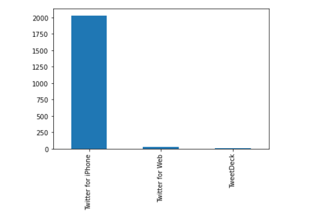

The most used source is ' Twitter for iPhone '

# Names

Dog names are an important part of a dog's identity and can reflect their personality or even their owner's personal preferences. Of the many dog names out there Charlie,Lucy,Oliver,Cooper, and penny are among the most popular names on the account

| Name | Count |
| --- | --- |
| Charlie | 11 |
| Lucy | 10 |
| Oliver | 10 |
| Cooper | 10 |
| Penny | 9 |